# Statistical Analysis

Elena Marochkina

2024-11-11

# 1. Outcomes Data

## 1.1. Read Data

## 1.2. Desriptive Statistics and Visualisation Analysis

### 1.2.1. Outcome 1: Death Status

| Variable | Value | n | % by group | No data |
| --- | --- | --- | --- | --- |
| EXPIRE_FLAG | 0 | 30,761 | 66.12425 | 0 |
|  | 1 | 15,759 | 33.87575 | 0 |

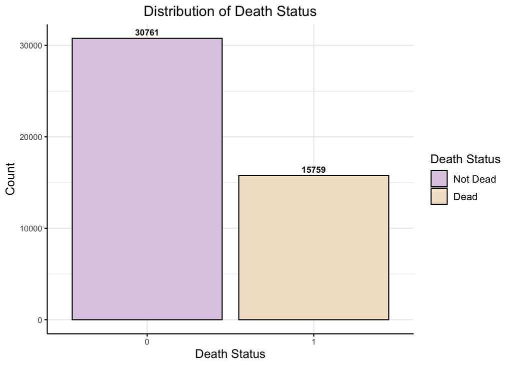

- There were 30,761 patients who did not die (labeled “Not Dead”).
- There were 15,759 patients who died (labeled “Dead”).

This indicates that a higher proportion of patients in the dataset survived compared to those who did not. The ratio of surviving patients to deceased patients is approximately 2:1, which suggests that while mortality is significant, more patients survived than passed away during the period considered.

### 1.2.2. Outcome 2: Length of Survival

| Variable | Stat | Value |
| --- | --- | --- |
| SURVIVAL | Number of values | 46520 |
|  | No data | 0 |
|  | Mean | 12.85 |
|  | Median | 7.25 |
|  | SD | 17.33 |
|  | Q1 - Q3 | 3.96 - 14.74 |
|  | IQR | 10.78 |
|  | 95% CI | 12.7 - 13.01 |
|  | min | 0 |
|  | max | 328.55 |

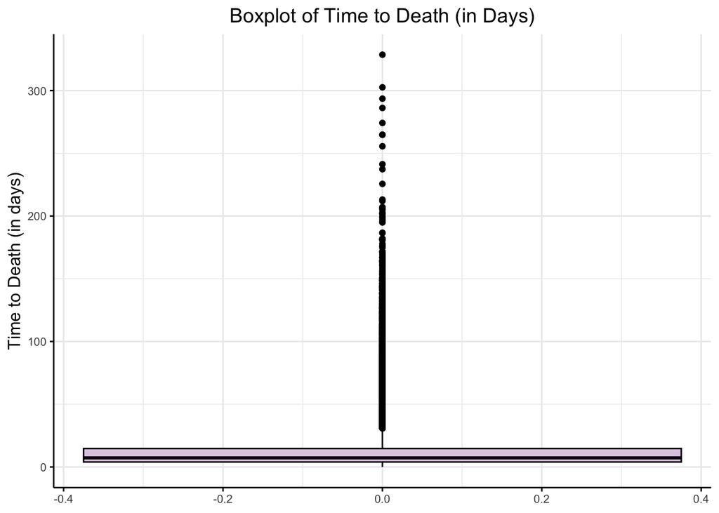

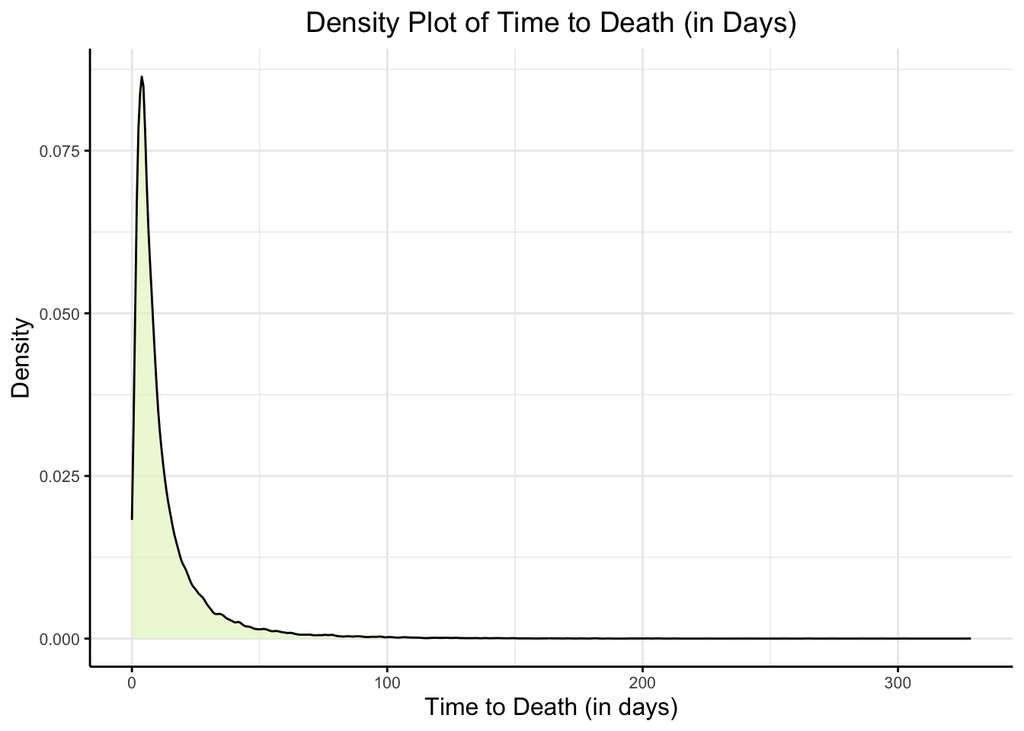

### 1.2.3. Outcome 3: Length of ICU Stay

| Variable | Stat | Value |
| --- | --- | --- |
| LOS | Number of values | 61522 |
|  | No data | 10 |
|  | Mean | 4.92 |
|  | Median | 2.09 |
|  | SD | 9.64 |
|  | Q1 - Q3 | 1.11 - 4.48 |
|  | IQR | 3.38 |
|  | 95% CI | 4.84 - 4.99 |
|  | min | 0 |
|  | max | 173.07 |

**Check for outliers**

```
## Number of outliers in LOS: 1198
```

```
## Percentage of outliers in LOS: 1.95 %
```

Based on the relatively small percentage of outliers (1.95%), it was decided to filter them out from the icu_stays dataset. This filtering helps ensure a more robust analysis by excluding extreme cases that could disproportionately impact the results. It’s worth noting that some of these outliers could represent unique cases, such as patients in a coma or those with extended ICU stays due to complex medical conditions.

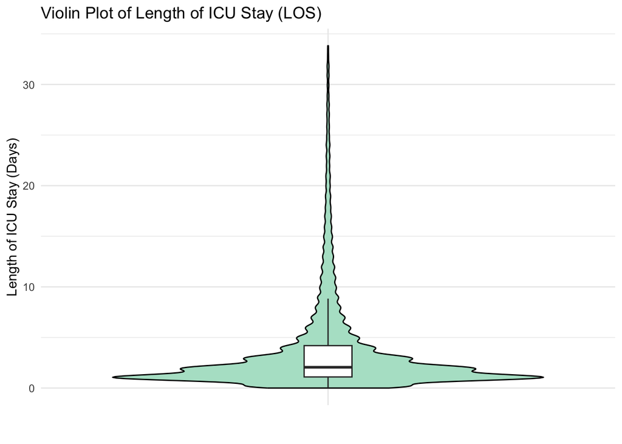

This plot highlights that most patients had shorter ICU stays, but there are a few cases with extended durations that could represent unique medical conditions or complications.

# 2. Patients Data

## 2.1. Read and Prepare Data

Data summary

| Name | patients |
| --- | --- |
| Number of rows | 46520 |
| Number of columns | 8 |
| _______________________ |  |
| Column type frequency: |  |
| factor | 2 |
| numeric | 4 |
| POSIXct | 2 |
| ________________________ |  |
| Group variables | None |

**Variable type: factor**

| skim_variable | n_missing | complete_rate | ordered | n_unique | top_counts |
| --- | --- | --- | --- | --- | --- |
| GENDER | 0 | 1 | FALSE | 2 | M: 26121, F: 20399 |
| EXPIRE_FLAG | 0 | 1 | FALSE | 2 | 0: 30761, 1: 15759 |

**Variable type: numeric**

| skim_variable | n_missing | complete_rate | mean | sd | p0 | p25 | p50 | p75 | p100 | hist |
| --- | --- | --- | --- | --- | --- | --- | --- | --- | --- | --- |
| ROW_ID | 0 | 1 | 23260.50 | 13429.31 | 1 | 11630.75 | 23260.5 | 34890.25 | 46520 | ▇▇▇▇▇ |
| SUBJECT_ID | 0 | 1 | 34425.77 | 28330.40 | 2 | 12286.75 | 24650.5 | 55477.50 | 99999 | ▇▅▂▂▂ |
| AGE_AT_ADMISSION | 83 | 1 | 52.89 | 28.77 | 0 | 39.00 | 60.0 | 76.00 | 93 | ▅▂▅▇▇ |
| AGE_AT_DEATH | 83 | 1 | 52.89 | 28.77 | 0 | 39.00 | 60.0 | 76.00 | 93 | ▅▂▅▇▇ |

**Variable type: POSIXct**

| skim_variable | n_missing | complete_rate | min | max | median | n_unique |
| --- | --- | --- | --- | --- | --- | --- |
| DOB | 0 | 1.00 | 1800-07-02 | 2201-07-24 | 2096-07-11 | 32540 |
| DOD | 30761 | 0.34 | 2100-06-19 | 2211-06-10 | 2152-07-06 | 12911 |

## 2.2. Desriptive statistics

### 2.2.1. Descriptive statistics for numerical variables

| Variable | Stat | Value |
| --- | --- | --- |
| AGE_AT_ADMISSION | Number of values | 46437 |
|  | No data | 83 |
|  | Mean | 52.89 |
|  | Median | 60 |
|  | SD | 28.77 |
|  | Q1 - Q3 | 39 - 76 |
|  | IQR | 37 |
|  | 95% CI | 52.63 - 53.15 |
|  | min | 0 |
|  | max | 93 |
| AGE_AT_DEATH | Number of values | 46437 |
|  | No data | 83 |
|  | Mean | 52.89 |
|  | Median | 60 |
|  | SD | 28.77 |
|  | Q1 - Q3 | 39 - 76 |
|  | IQR | 37 |
|  | 95% CI | 52.63 - 53.15 |
|  | min | 0 |
|  | max | 93 |

### 2.2.2. Descriptive statistics for categorical variables

| Variable | Value | n | % by group | No data |
| --- | --- | --- | --- | --- |
| EXPIRE_FLAG | 0 | 30,761 | 66.12425 | 0 |
|  | 1 | 15,759 | 33.87575 | 0 |
| GENDER | F | 20,399 | 43.84996 | 0 |
|  | M | 26,121 | 56.15004 | 0 |

## 2.3. Visualisation Analysis by Outcome

### 2.3.1. Outcome 1: Death Status by Patients Data

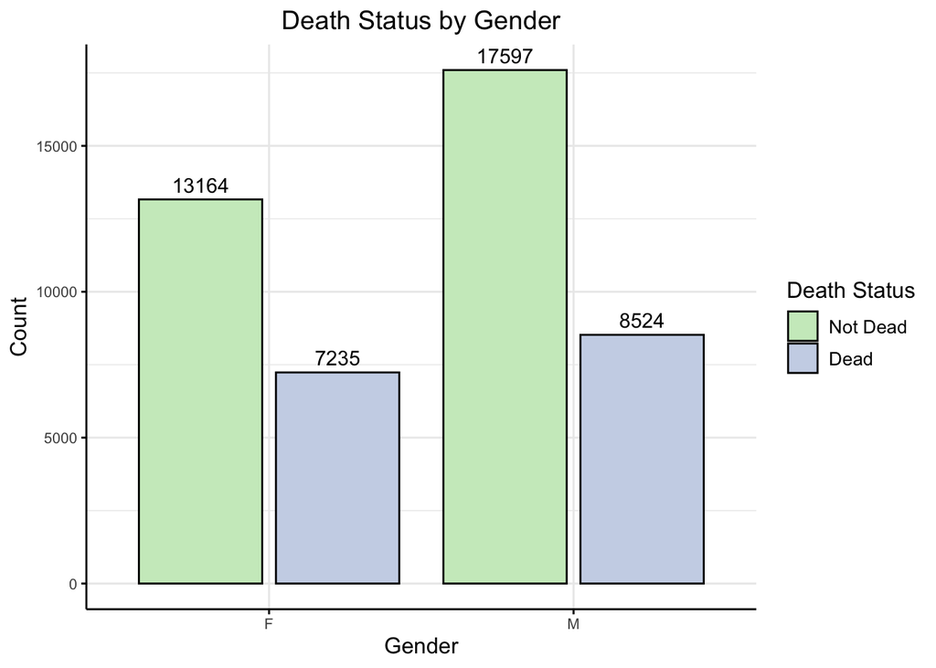

- Males (M) have a higher count in both survival (17,597) and death (8,524) categories compared to females.
- Females (F) have a lower count, with 13,164 surviving and 7,235 deceased.

This suggests that while the total number of male patients is higher, the proportion of deceased individuals appears similar across genders.

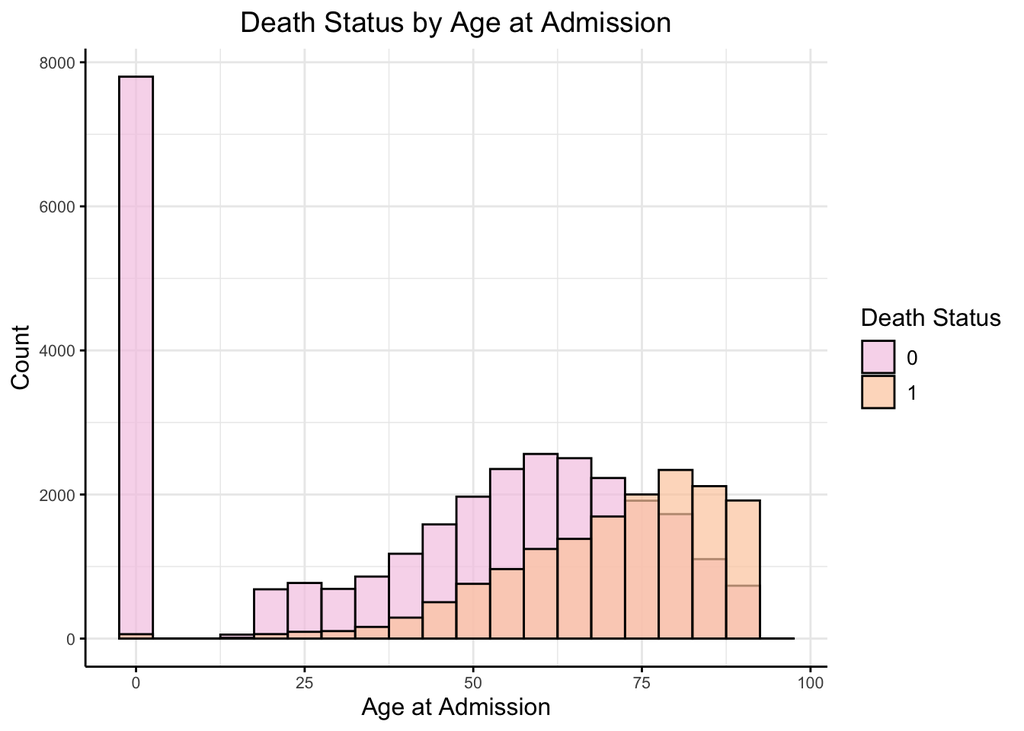

- High Frequency in Infants (Age 0): There is a significant spike in the number of admissions at age 0, with the vast majority being alive.
- Increasing Death Rate with Age: The number of deaths increases as age at admission increases, particularly noticeable in older age groups (60+ years). This suggests a higher mortality rate with increasing age.
- Peak in Midlife and Elderly: The number of admissions peaks around middle age (45–65) with a higher number of surviving patients but a noticeable increase in death cases as age progresses.

### 2.3.2. Outcome 2: Length of Survival by Patients Data

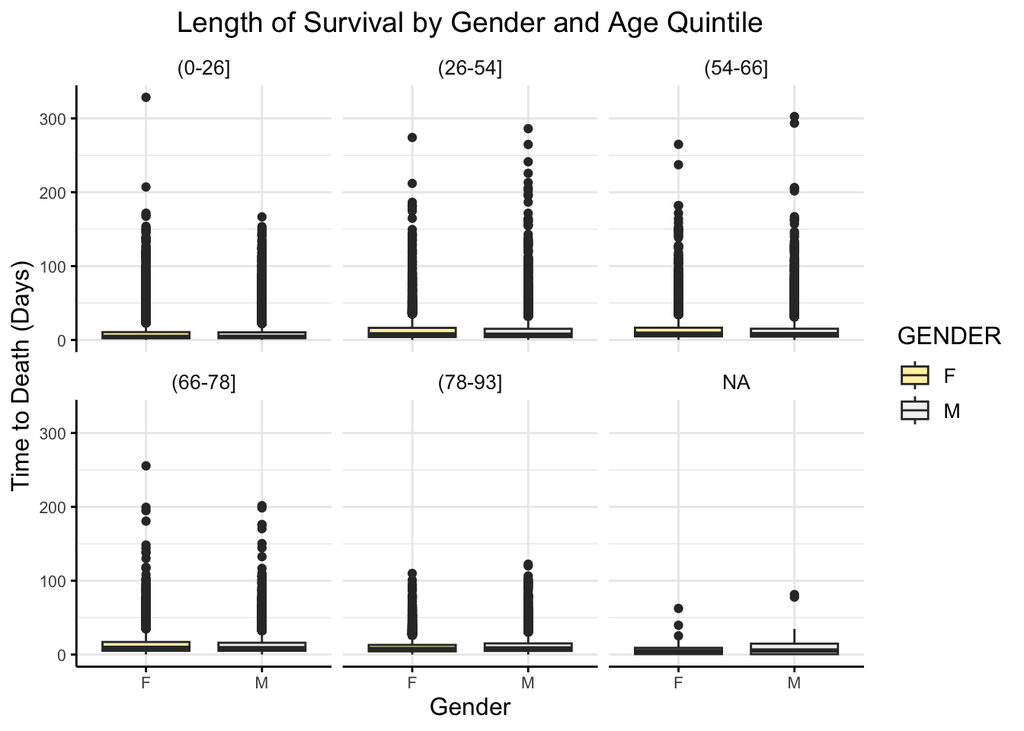

The plot allows for the visualization of how gender and age interact to influence survival times. It suggests that older females tend to have longer survival times than older males, but there are significant outliers in each group. The presence of NA age values indicates patients whose age could not be determined.

### 2.3.3. Outcome 3: Length of ICU Stay by Patients Data

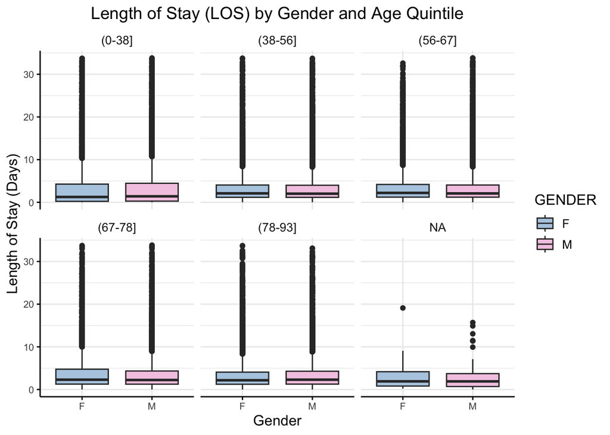

## 2.4. Exploratory analysis

### 2.4.1. Outcome 1: Death Status by Patients Data

```
## # A tibble: 2 × 4
##   Variable Performed_test      Result  Interpretation
##   <chr>    <chr>               <chr>   <chr>
## 1 Age      Mann-Whitney U Test <2e-16  Significant
## 2 Gender   Chi-Squared Test    1.6e-10 Significant
```

Both **Age and Gender** show highly significant associations with death status (EXPIRE_FLAG), suggesting they are both important variables in explaining survival outcomes in this dataset.

### 2.4.2. Outcome 2: Length of Survival by Patients Data

```
##                          Variable Hazard_Ratio Lower_CI Upper_CI  p_value
## GENDERM                    GENDER    0.9789031 0.948572 1.010204 1.84e-01
## AGE_AT_ADMISSION AGE_AT_ADMISSION    1.0372342 1.036219 1.038251 < 0.0001
```

**GENDER:** There is no statistically significant effect of gender on survival in your data. The p-value for gender is above the typical threshold of 0.05, and the confidence interval includes 1, indicating no strong evidence of an association.

**AGE_AT_ADMISSION:** Age is a significant predictor of survival. The positive hazard ratio of 1.04 means that older patients are at a slightly higher risk of the event (death, etc.), and this result is statistically significant (p-value < 0.0001).

# 3. Admissions Data

## 3.1. Read and Prepare Data

Data summary

| Name | admissions |
| --- | --- |
| Number of rows | 58949 |
| Number of columns | 11 |
| _______________________ |  |
| Column type frequency: |  |
| factor | 5 |
| numeric | 3 |
| POSIXct | 3 |
| ________________________ |  |
| Group variables | None |

**Variable type: factor**

| skim_variable | n_missing | complete_rate | ordered | n_unique | top_counts |
| --- | --- | --- | --- | --- | --- |
| ADMISSION_TYPE | 0 | 1 | FALSE | 4 | EME: 42047, NEW: 7863, ELE: 7704, URG: 1335 |
| INSURANCE | 0 | 1 | FALSE | 5 | MED: 28212, PRI: 22559, MED: 5785, GOV: 1783 |
| RELIGION | 0 | 1 | FALSE | 4 | CHR: 29857, UNK: 20464, JUD: 5328, OTH: 3300 |
| MARITAL_STATUS | 0 | 1 | FALSE | 7 | MAR: 24230, SIN: 13246, UNK: 10464, WID: 7210 |
| ETHNICITY | 0 | 1 | FALSE | 5 | WHI: 43601, UNK: 5890, BLA: 5784, ASI: 2007 |

**Variable type: numeric**

| skim_variable | n_missing | complete_rate | mean | sd | p0 | p25 | p50 | p75 | p100 | hist |
| --- | --- | --- | --- | --- | --- | --- | --- | --- | --- | --- |
| SUBJECT_ID | 0 | 1 | 33763.65 | 28096.05 | 2 | 11999.00 | 24141.00 | 53864.0 | 99999.00 | ▇▅▂▂▂ |
| HADM_ID | 0 | 1 | 149971.23 | 28884.03 | 100001 | 124952.00 | 149989.00 | 174972.0 | 199999.00 | ▇▇▇▇▇ |
| SURVIVAL | 0 | 1 | 10.14 | 12.46 | 0 | 3.75 | 6.47 | 11.8 | 294.66 | ▇▁▁▁▁ |

**Variable type: POSIXct**

| skim_variable | n_missing | complete_rate | min | max | median | n_unique |
| --- | --- | --- | --- | --- | --- | --- |
| ADMITTIME | 73 | 1.0 | 2100-06-07 19:59:00 | 2210-08-17 17:13:00 | 2151-01-18 09:12:00 | 58551 |
| DISCHTIME | 73 | 1.0 | 2100-06-07 19:59:00 | 2210-08-17 17:13:00 | 2151-01-18 09:12:00 | 58551 |
| DEATHTIME | 53185 | 0.1 | 2100-06-19 08:15:00 | 2208-02-05 11:45:00 | 2150-10-09 03:18:00 | 5744 |

## 3.2. Desriptive statistics

### 3.2.1. Descriptive statistics for categorical variables

| Variable | Value | n | % by group | No data |
| --- | --- | --- | --- | --- |
| ADMISSION_TYPE | ELECTIVE | 7,704 | 13.06892399 | 0 |
|  | EMERGENCY | 42,047 | 71.32775789 | 0 |
|  | NEWBORN | 7,863 | 13.33864866 | 0 |
|  | URGENT | 1,335 | 2.26466946 | 0 |
| ETHNICITY | OTHER | 1,667 | 2.82786816 | 0 |
|  | UNKNOWN | 5,890 | 9.99168773 | 0 |
|  | ASIAN | 2,007 | 3.40463791 | 0 |
|  | BLACK | 5,784 | 9.81187128 | 0 |
|  | WHITE | 43,601 | 73.96393493 | 0 |
| INSURANCE | GOVERNMENT | 1,783 | 3.02464842 | 0 |
|  | MEDICAID | 5,785 | 9.81356766 | 0 |
|  | MEDICARE | 28,212 | 47.85831821 | 0 |
|  | PRIVATE | 22,559 | 38.26867292 | 0 |
|  | SELF PAY | 610 | 1.03479279 | 0 |
| MARITAL_STATUS | UNKNOWN | 10,464 | 17.75093725 | 0 |
|  | DIVORCED | 3,213 | 5.45047414 | 0 |
|  | LIFE PARTNER | 15 | 0.02544572 | 0 |
|  | MARRIED | 24,230 | 41.10332660 | 0 |
|  | SEPARATED | 571 | 0.96863390 | 0 |
|  | SINGLE | 13,246 | 22.47027091 | 0 |
|  | WIDOWED | 7,210 | 12.23091147 | 0 |
| RELIGION | CHRISTIANITY | 29,857 | 50.64886597 | 0 |
|  | JUDAISM | 5,328 | 9.03832126 | 0 |
|  | OTHER | 3,300 | 5.59805934 | 0 |
|  | UNKNOWN | 20,464 | 34.71475343 | 0 |

## 3.3. Visualisation Analysis by Outcome

### 3.3.1. Outcome 1: Death Status by Admissions Data

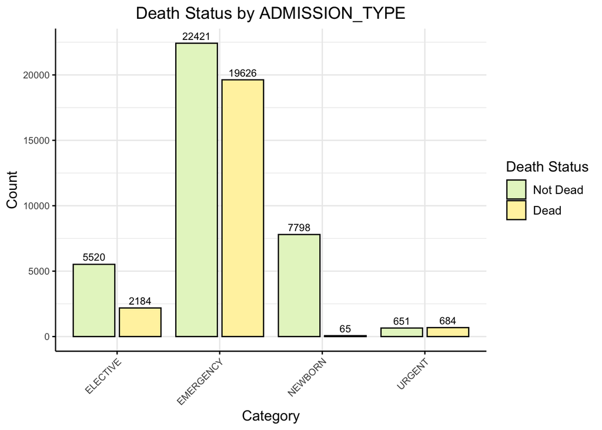

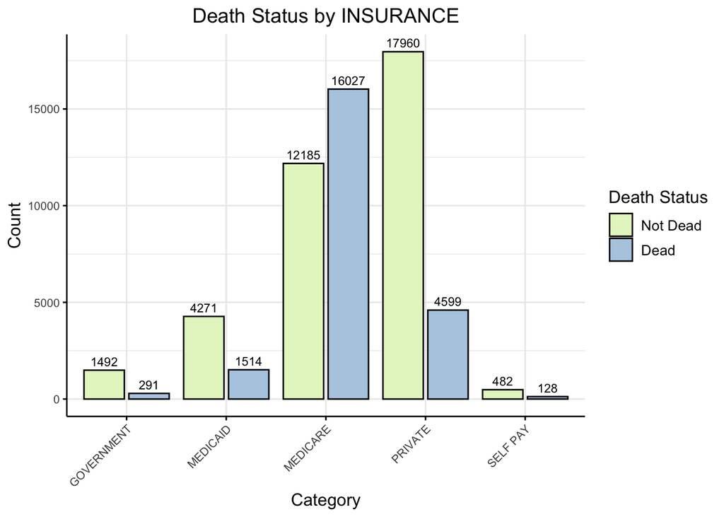

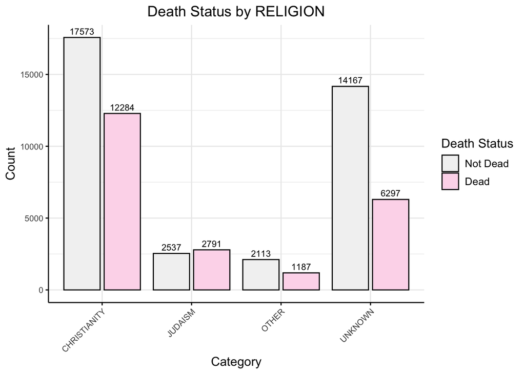

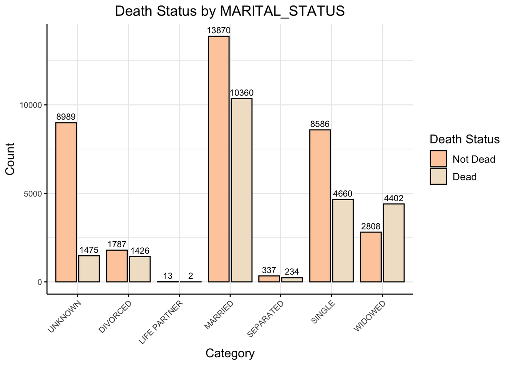

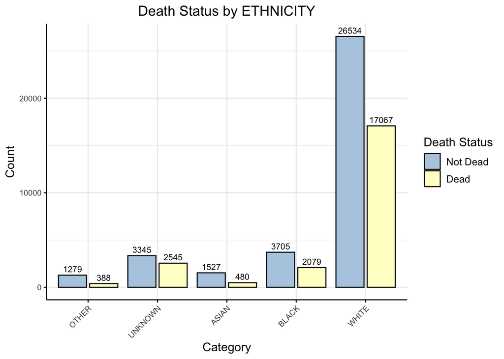

## 3.4. Exploratory analysis

```
## # A tibble: 5 × 4
##   Variable       Performed_test   Result Interpretation
##   <chr>          <chr>            <chr>  <chr>
## 1 ADMISSION TYPE Chi-Squared Test <2e-16 Significant
## 2 INSURANCE      Chi-Squared Test <2e-16 Significant
## 3 RELIGION       Chi-Squared Test <2e-16 Significant
## 4 MARITAL_STATUS Chi-Squared Test <2e-16 Significant
## 5 ETHNICITY      Chi-Squared Test <2e-16 Significant
```